# Análisis de Componentes Principales (PCA) — Leonard et al. (2021)

2026-06-29

Este script realiza el análisis exploratorio de las tres matrices ómicas mediante PCA.

# 1. Carga de librerías

```r
library(tidyverse)
library(PLSandO)
library(gridExtra)
library(knitr)
library(here)
```

# 2. Carga de datos preprocesados

```r
processed_dir <- here("data", "processed", "leonard_2021")

species_clr_data     <- readRDS(file.path(processed_dir, "species_clr_data.rds"))
pathways_clr_data    <- readRDS(file.path(processed_dir, "pathways_clr_data.rds"))
metabolites_log_data <- readRDS(file.path(processed_dir, "metabolites_log_data.rds"))

dim(species_clr_data)
```

```
## [1] 118 156
```

```r
dim(pathways_clr_data)
```

```
## [1] 118 119
```

```r
dim(metabolites_log_data)
```

```
## [1] 118  75
```

# 3. Separación de metadatos y matrices numéricas

Para el PCA se necesita únicamente la matriz numérica. Se separan los metadatos (que se usarán para colorear los plots) de las variables ómicas. Se asignan los identificadores de muestra como nombres de fila para que los plots de scores puedan identificarlas si fuera necesario.

```r
metadata_cols <- c(
  "sample_id", "PaperID", "group", "pair_id",
  "time_label", "TimePoint", "relative_time_label",
  "sample_month", "onset_month", "relative_month",
  "Country", "Gender", "Delivery_Mode", "Genetic_Risk"
)

species_meta <- species_clr_data %>% select(any_of(metadata_cols))
species_X    <- species_clr_data %>%
  select(-any_of(metadata_cols)) %>%
  mutate(across(everything(), as.numeric)) %>%
  as.data.frame()
rownames(species_X) <- species_meta$sample_id

pathways_meta <- pathways_clr_data %>% select(any_of(metadata_cols))
pathways_X    <- pathways_clr_data %>%
  select(-any_of(metadata_cols)) %>%
  mutate(across(everything(), as.numeric)) %>%
  as.data.frame()
rownames(pathways_X) <- pathways_meta$sample_id

metabolites_meta <- metabolites_log_data %>% select(any_of(metadata_cols))
metabolites_X    <- metabolites_log_data %>%
  select(-any_of(metadata_cols)) %>%
  mutate(across(everything(), as.numeric)) %>%
  as.data.frame()
rownames(metabolites_X) <- metabolites_meta$sample_id
```

# Nota sobre el escalado empleado

Para cada matriz ómica (species, pathways, metabolites) se presenta primero el PCA con escalado `center` (solo centrado, sin dividir por la desviación típica de cada variable) y a continuación con escalado `standard` (centrado + escalado a varianza unitaria).

# 4. PCA — Species

## 4.1 Escalado: center

### 4.1.1 Cálculo y scree plot

Se calcula el PCA sobre la matriz de especies con escalado center (solo centrado, sin dividir por la desviación típica). El scree plot muestra la varianza explicada por cada componente principal, lo que ayuda a decidir cuántas componentes son informativas.

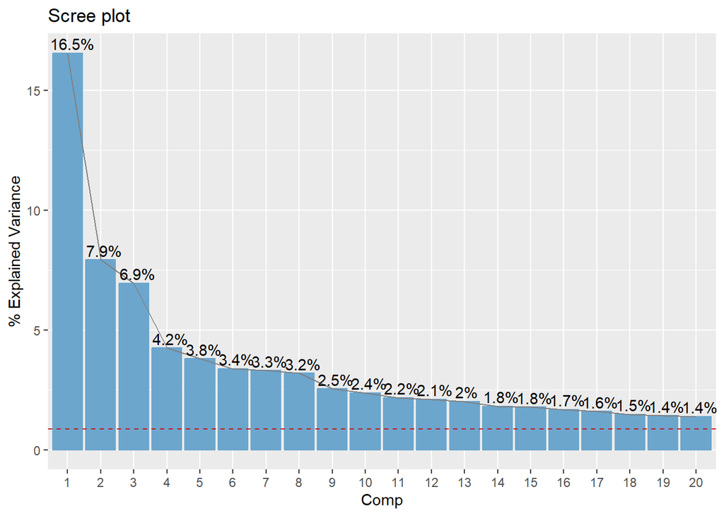

```r
species_pca_center <- pca(
  species_X,
  ncomp   = NULL,
  algo    = "nipals",
  scaling = "center"
)

pcaPlot(species_pca_center, type = "scree")
```

### 4.1.2 Score plots — coloreando por covariables de interés

#### Grupo (caso/control)

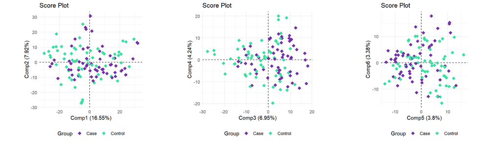

```r
p1 <- pcaPlot(species_pca_center, type = "scores", comp = 1:2,
              colBy = data.frame(Group = species_meta$group),
              labels = FALSE, ellipses = FALSE)
p2 <- pcaPlot(species_pca_center, type = "scores", comp = 3:4,
              colBy = data.frame(Group = species_meta$group),
              labels = FALSE, ellipses = FALSE)
p3 <- pcaPlot(species_pca_center, type = "scores", comp = 5:6,
              colBy = data.frame(Group = species_meta$group),
              labels = FALSE, ellipses = FALSE)

grid.arrange(p1, p2, p3, nrow = 1)
```

#### Tiempo relativo al diagnóstico

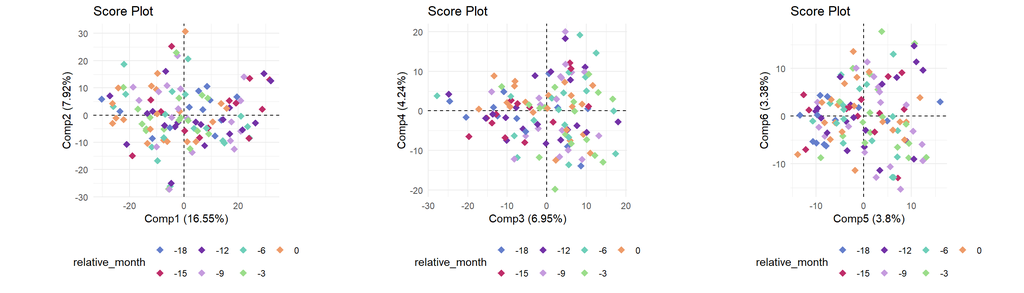

```r
species_time <- factor(species_meta$relative_month,
                       levels = c(-18, -15, -12, -9, -6, -3, 0))

p1 <- pcaPlot(species_pca_center, type = "scores", comp = 1:2,
              colBy = data.frame(relative_month = species_time),
              labels = FALSE, ellipses = FALSE)
p2 <- pcaPlot(species_pca_center, type = "scores", comp = 3:4,
              colBy = data.frame(relative_month = species_time),
              labels = FALSE, ellipses = FALSE)
p3 <- pcaPlot(species_pca_center, type = "scores", comp = 5:6,
              colBy = data.frame(relative_month = species_time),
              labels = FALSE, ellipses = FALSE)

grid.arrange(p1, p2, p3, nrow = 1)
```

#### País

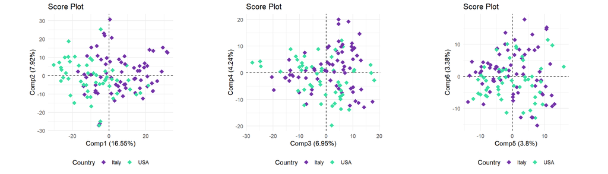

```r
p1 <- pcaPlot(species_pca_center, type = "scores", comp = 1:2,
              colBy = data.frame(Country = species_meta$Country),
              labels = FALSE, ellipses = FALSE)
p2 <- pcaPlot(species_pca_center, type = "scores", comp = 3:4,
              colBy = data.frame(Country = species_meta$Country),
              labels = FALSE, ellipses = FALSE)
p3 <- pcaPlot(species_pca_center, type = "scores", comp = 5:6,
              colBy = data.frame(Country = species_meta$Country),
              labels = FALSE, ellipses = FALSE)

grid.arrange(p1, p2, p3, nrow = 1)
```

#### Sexo

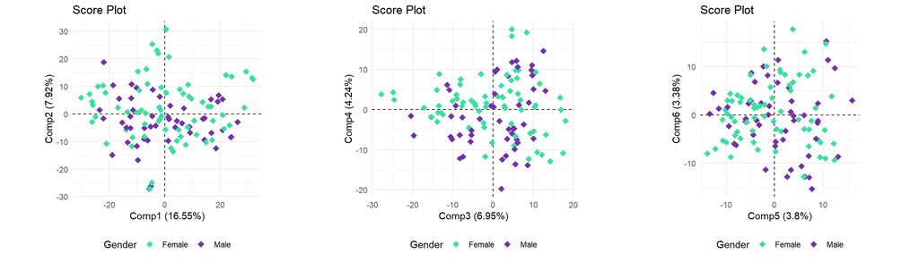

```r
p1 <- pcaPlot(species_pca_center, type = "scores", comp = 1:2,
              colBy = data.frame(Gender = species_meta$Gender),
              labels = FALSE, ellipses = FALSE)
p2 <- pcaPlot(species_pca_center, type = "scores", comp = 3:4,
              colBy = data.frame(Gender = species_meta$Gender),
              labels = FALSE, ellipses = FALSE)
p3 <- pcaPlot(species_pca_center, type = "scores", comp = 5:6,
              colBy = data.frame(Gender = species_meta$Gender),
              labels = FALSE, ellipses = FALSE)

grid.arrange(p1, p2, p3, ncol = 3)
```

#### Tipo de parto

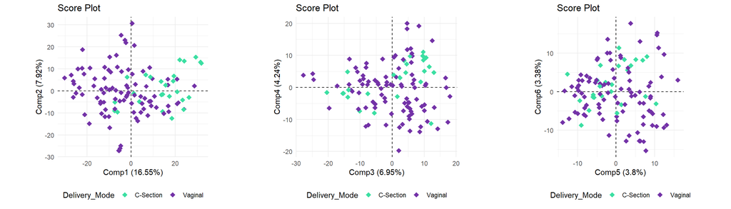

```r
p1 <- pcaPlot(species_pca_center, type = "scores", comp = 1:2,
              colBy = data.frame(Delivery_Mode = species_meta$Delivery_Mode),
              labels = FALSE, ellipses = FALSE)
p2 <- pcaPlot(species_pca_center, type = "scores", comp = 3:4,
              colBy = data.frame(Delivery_Mode = species_meta$Delivery_Mode),
              labels = FALSE, ellipses = FALSE)
p3 <- pcaPlot(species_pca_center, type = "scores", comp = 5:6,
              colBy = data.frame(Delivery_Mode = species_meta$Delivery_Mode),
              labels = FALSE, ellipses = FALSE)

grid.arrange(p1, p2, p3, ncol = 3)
```

#### Riesgo genético (HLA)

Los nombres de los perfiles de riesgo genético son largos, por lo que se abrevian para mejorar la legibilidad de la leyenda. La leyenda se muestra solo en el panel central.

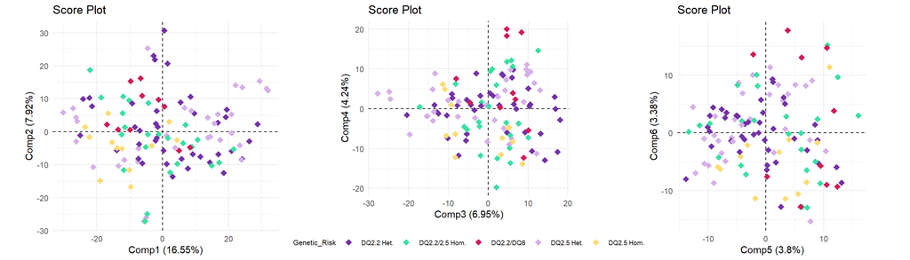

```r
genetic_risk_short <- species_meta$Genetic_Risk %>%
  str_replace_all("Homozygous", "Hom.") %>%
  str_replace_all("Heterozygous", "Het.")

p1 <- pcaPlot(species_pca_center, type = "scores", comp = 1:2,
              colBy = data.frame(Genetic_Risk = genetic_risk_short),
              labels = FALSE, ellipses = FALSE) +
  theme(legend.position = "none")

p2 <- pcaPlot(species_pca_center, type = "scores", comp = 3:4,
              colBy = data.frame(Genetic_Risk = genetic_risk_short),
              labels = FALSE, ellipses = FALSE) +
  theme(legend.position = "bottom",
        legend.text  = element_text(size = 7),
        legend.title = element_text(size = 8))

p3 <- pcaPlot(species_pca_center, type = "scores", comp = 5:6,
              colBy = data.frame(Genetic_Risk = genetic_risk_short),
              labels = FALSE, ellipses = FALSE) +
  theme(legend.position = "none")

grid.arrange(p1, p2, p3, ncol = 3)
```

### 4.1.3 Loadings — correlation plots y top variables

Los loadings indican qué especies contribuyen más a cada componente principal. El correlation plot muestra la correlación de cada variable con los ejes del PCA, coloreada por su contribución. Las tablas muestran las 10 especies con mayor contribución a cada par de componentes, lo que permite interpretar qué está impulsando la variabilidad capturada.

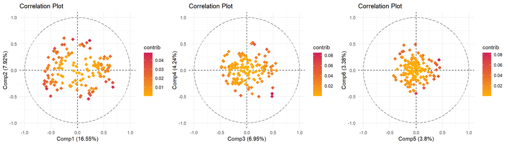

```r
l1 <- pcaPlot(species_pca_center, type = "corr", comp = 1:2,
              colBy = "contrib", shape = "point",
              labels = FALSE, repel = TRUE, col = "hot")
l2 <- pcaPlot(species_pca_center, type = "corr", comp = 3:4,
              colBy = "contrib", shape = "point",
              labels = FALSE, repel = TRUE, col = "hot")
l3 <- pcaPlot(species_pca_center, type = "corr", comp = 5:6,
              colBy = "contrib", shape = "point",
              labels = FALSE, repel = TRUE, col = "hot")

grid.arrange(l1, l2, l3, ncol = 3)
```

**Top 10 especies — PC1 y PC2**

```r
species_top_PC12_center <- tibble(
  variable    = rownames(species_pca_center$loadings),
  loading_PC1 = species_pca_center$loadings[, 1],
  loading_PC2 = species_pca_center$loadings[, 2]
) %>%
  mutate(contribution_PC12 = loading_PC1^2 + loading_PC2^2) %>%
  arrange(desc(contribution_PC12)) %>%
  slice_head(n = 10)

kable(species_top_PC12_center)
```

| variable | loading_PC1 | loading_PC2 | contribution_PC12 |
| --- | --- | --- | --- |
| Bifidobacterium.adolescentis | 0.0601150 | 0.2115605 | 0.0483716 |
| Veillonella.sp. | 0.1765220 | -0.1212620 | 0.0458645 |
| Bacteroides.vulgatus | -0.1588482 | -0.1380661 | 0.0442950 |
| Erysipelotrichaceae.bacterium | 0.0537395 | -0.2034851 | 0.0442941 |
| Bifidobacterium.pseudocatenulatum | -0.0213640 | 0.2063052 | 0.0430183 |
| Bacteroides.sp. | -0.1145067 | -0.1597798 | 0.0386414 |
| Bacteroides.ovatus | -0.1649839 | -0.0963676 | 0.0365064 |
| Veillonella.dispar | 0.1624083 | -0.0829342 | 0.0332545 |
| Eubacterium.hallii | -0.1060032 | 0.1471726 | 0.0328964 |
| Veillonella.parvula | 0.1550888 | -0.0897363 | 0.0321051 |

**Top 10 especies — PC3 y PC4**

```r
species_top_PC34_center <- tibble(
  variable    = rownames(species_pca_center$loadings),
  loading_PC3 = species_pca_center$loadings[, 3],
  loading_PC4 = species_pca_center$loadings[, 4]
) %>%
  mutate(contribution_PC34 = loading_PC3^2 + loading_PC4^2) %>%
  arrange(desc(contribution_PC34)) %>%
  slice_head(n = 10)

kable(species_top_PC34_center)
```

| variable | loading_PC3 | loading_PC4 | contribution_PC34 |
| --- | --- | --- | --- |
| Eggerthella.sp. | 0.1884965 | -0.2225917 | 0.0850780 |
| Eggerthella.lenta | 0.1714830 | -0.2278946 | 0.0813424 |
| Dialister.invisus | 0.0525967 | 0.2286383 | 0.0550419 |
| Peptoclostridium.difficile | 0.1707161 | -0.1481585 | 0.0510949 |
| Clostridium.bolteae | 0.1316629 | 0.1763267 | 0.0484262 |
| Streptococcus.sp. | -0.0377531 | -0.2025689 | 0.0424594 |
| Ruminococcus.obeum | 0.0674053 | -0.1889655 | 0.0402514 |
| Prevotella.buccae | 0.0325715 | 0.1941268 | 0.0387461 |
| Streptococcus.parasanguinis | -0.0750617 | -0.1721233 | 0.0352607 |
| Erysipelotrichaceae.bacterium | 0.1869288 | -0.0028780 | 0.0349507 |

**Top 10 especies — PC5 y PC6**

```r
species_top_PC56_center <- tibble(
  variable    = rownames(species_pca_center$loadings),
  loading_PC5 = species_pca_center$loadings[, 5],
  loading_PC6 = species_pca_center$loadings[, 6]
) %>%
  mutate(contribution_PC56 = loading_PC5^2 + loading_PC6^2) %>%
  arrange(desc(contribution_PC56)) %>%
  slice_head(n = 10)

kable(species_top_PC56_center)
```

| variable | loading_PC5 | loading_PC6 | contribution_PC56 |
| --- | --- | --- | --- |
| Veillonella.parvula | 0.2599394 | 0.1264598 | 0.0835606 |
| Haemophilus.parainfluenzae | -0.0013643 | -0.2653475 | 0.0704112 |
| Veillonella.dispar | 0.2266115 | 0.0260828 | 0.0520331 |
| Clostridium.hathewayi | -0.1534793 | 0.1644517 | 0.0506003 |
| Bacteroides.dorei | 0.2155775 | -0.0628663 | 0.0504258 |
| Veillonella.sp. | 0.2148868 | 0.0592237 | 0.0496838 |
| Subdoligranulum.sp. | -0.1189211 | 0.1874308 | 0.0492725 |
| Anaerostipes.hadrus | 0.0842202 | -0.2051170 | 0.0491660 |
| Bacteroides.vulgatus | 0.1924568 | -0.1011888 | 0.0472788 |
| Oscillospiraceae.bacterium | -0.0058561 | 0.2110616 | 0.0445813 |

Fijamos el número de componentes antes de estudiar los anómalos para evitar problemas con los gráficos.

```r
species_pca_center <- pca(
  species_X,
  ncomp   = 6,
  algo    = "nipals",
  scaling = "center"
)
```

### 4.1.4 Detección de muestras anómalas

Se detectan muestras anómalas mediante dos criterios complementarios. El RSS y el T² de Hotelling.

```r
par(mfrow = c(1, 2))

species_out_RSS_center <- pcaOutliers(species_pca_center, ncomp = species_pca_center$ncomp,
                               method = "RSS", conf = 0.95)
species_out_T2_center  <- pcaOutliers(species_pca_center, ncomp = species_pca_center$ncomp,
                               method = "T2",  conf = 0.95)
```

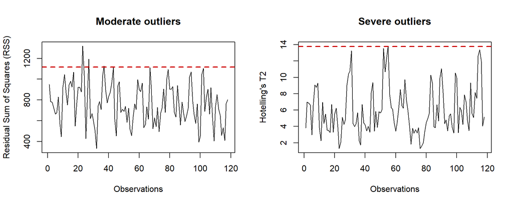

```r
par(mfrow = c(1, 1))
```

```r
species_moderate_center <- sort(
  species_out_RSS_center$RSS[species_out_RSS_center$ModerateOutliers],
  decreasing = TRUE
)

species_severe_center <- sort(
  species_out_T2_center$T2[species_out_T2_center$SevereOutliers],
  decreasing = TRUE
)

cat("Anómalos moderados (RSS) al 95 :\n"); print(species_moderate_center)
```

```
## Anómalos moderados (RSS) al 95 :
```

```
## Control_2_21_month    Case_3_12_month Control_3_21_month
##           1318.576           1193.883           1126.016
```

```r
cat("\nAnómalos severos (T²) al 95 :\n");   print(species_severe_center)
```

```
##
## Anómalos severos (T²) al 95 :
```

```
## Control_5_42_month
##           13.82851
```

```r
par(mfrow = c(1, 2))

species_out_RSS_99_center <- pcaOutliers(species_pca_center, ncomp = species_pca_center$ncomp,
                                  method = "RSS", conf = 0.99)
species_out_T2_99_center  <- pcaOutliers(species_pca_center, ncomp = species_pca_center$ncomp,
                                  method = "T2",  conf = 0.99)
```

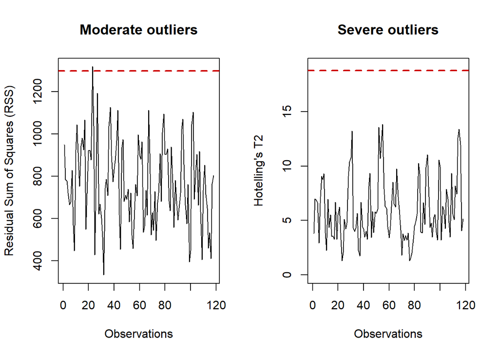

```r
par(mfrow = c(1, 1))
```

```r
moderate_99_center <- sort(species_out_RSS_99_center$RSS[species_out_RSS_99_center$ModerateOutliers],
                    decreasing = TRUE)
severe_99_center   <- sort(species_out_T2_99_center$T2[species_out_T2_99_center$SevereOutliers],
                    decreasing = TRUE)

cat("Moderados (RSS) al 99 :\n"); print(moderate_99_center)
```

```
## Moderados (RSS) al 99 :
```

```
## Control_2_21_month
##           1318.576
```

```r
cat("Severos   (T²) al 99 :\n");  print(severe_99_center)
```

```
## Severos   (T²) al 99 :
```

```
## named numeric(0)
```

```r
species_contrib_99_center <- outlierContrib(species_pca_center, species_out_RSS_99_center)
```

```
## There are no severe outliers in the data or they were not computed.
```

```
## There are 1 moderate outliers in the data provided.
```

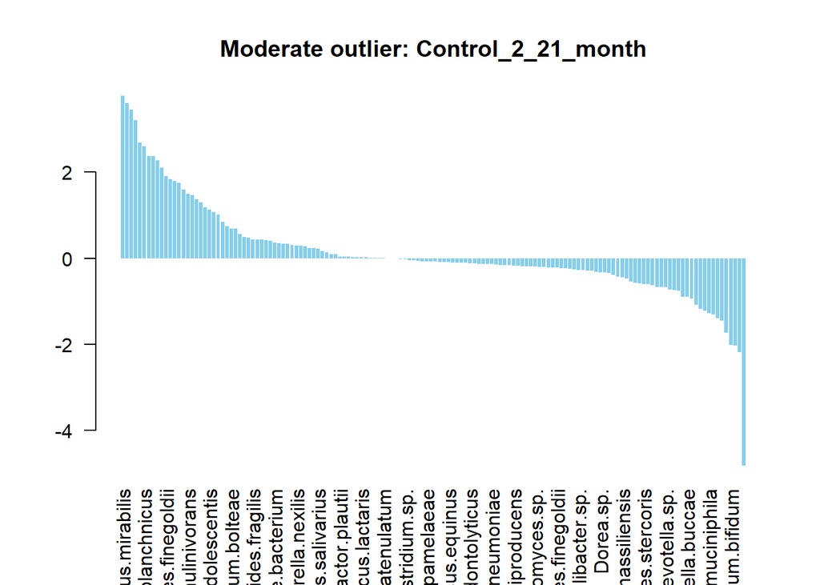

```r
contrib_vec_center <- species_contrib_99_center$contribRSS[1, ]
top10_center <- contrib_vec_center[order(abs(contrib_vec_center), decreasing = TRUE)][1:10]
top10_center
```

```
##              Anaerostipes.hadrus                Proteus.mirabilis
##                        -4.809297                         3.771737
## Parasutterella.excrementihominis             Enterococcus.faecium
##                         3.599813                         3.439940
##        Burkholderiales.bacterium            Klebsiella.pneumoniae
##                         3.205395                         2.685398
##         Odoribacter.splanchnicus                  Citrobacter.sp.
##                         2.597278                         2.375901
##             Citrobacter.freundii            Enterococcus.faecalis
##                         2.375521                         2.271430
```

Se reproduce el mismo flujo de trbajo tanto para Pathways como para Metabolites.

## 4.2 Escalado: standard

### 4.2.1 Cálculo y scree plot

Se calcula el PCA sobre la matriz de especies con escalado estándar. El scree plot muestra la varianza explicada por cada componente principal, lo que ayuda a decidir cuántas componentes son informativas.

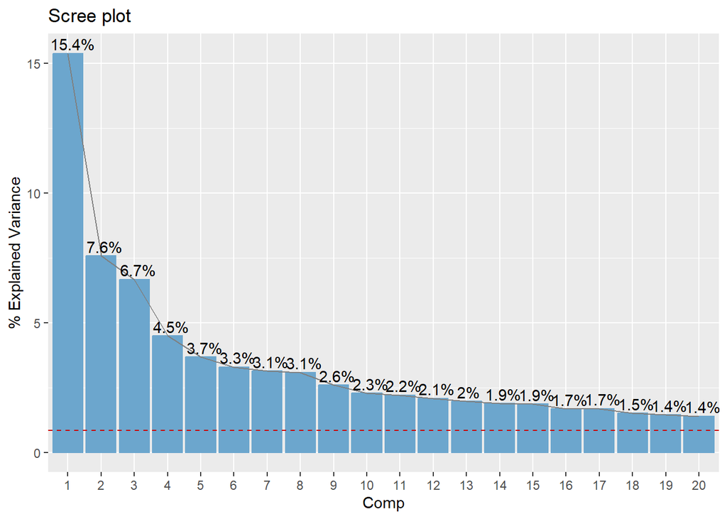

```r
species_pca <- pca(
  species_X,
  ncomp   = NULL,
  algo    = "nipals",
  scaling = "standard"
)

pcaPlot(species_pca, type = "scree")
```

### 4.2.2 Score plots — coloreando por covariables de interés

#### Grupo (caso/control)

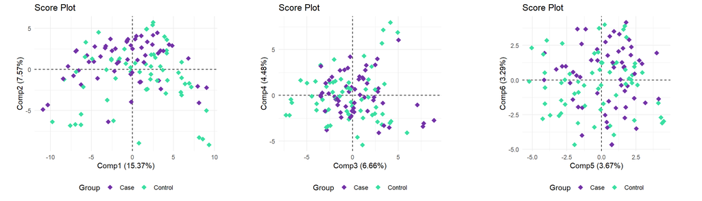

```r
p1 <- pcaPlot(species_pca, type = "scores", comp = 1:2,
              colBy = data.frame(Group = species_meta$group),
              labels = FALSE, ellipses = FALSE)
p2 <- pcaPlot(species_pca, type = "scores", comp = 3:4,
              colBy = data.frame(Group = species_meta$group),
              labels = FALSE, ellipses = FALSE)
p3 <- pcaPlot(species_pca, type = "scores", comp = 5:6,
              colBy = data.frame(Group = species_meta$group),
              labels = FALSE, ellipses = FALSE)

grid.arrange(p1, p2, p3, nrow = 1)
```

#### Tiempo relativo al diagnóstico

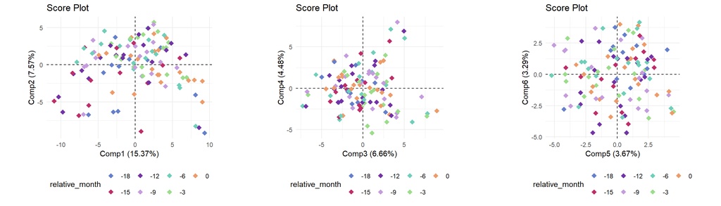

```r
species_time <- factor(species_meta$relative_month,
                       levels = c(-18, -15, -12, -9, -6, -3, 0))

p1 <- pcaPlot(species_pca, type = "scores", comp = 1:2,
              colBy = data.frame(relative_month = species_time),
              labels = FALSE, ellipses = FALSE)
p2 <- pcaPlot(species_pca, type = "scores", comp = 3:4,
              colBy = data.frame(relative_month = species_time),
              labels = FALSE, ellipses = FALSE)
p3 <- pcaPlot(species_pca, type = "scores", comp = 5:6,
              colBy = data.frame(relative_month = species_time),
              labels = FALSE, ellipses = FALSE)

grid.arrange(p1, p2, p3, nrow = 1)
```

#### País

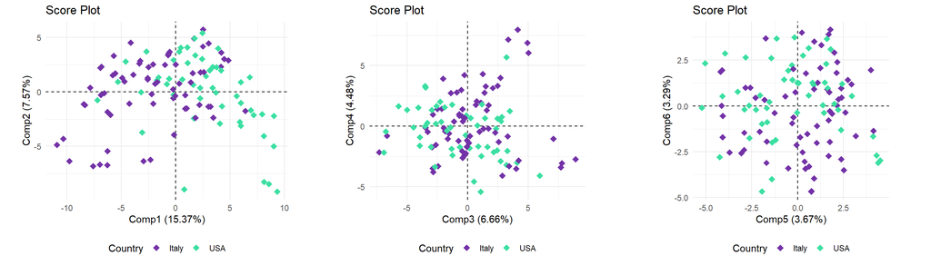

```r
p1 <- pcaPlot(species_pca, type = "scores", comp = 1:2,
              colBy = data.frame(Country = species_meta$Country),
              labels = FALSE, ellipses = FALSE)
p2 <- pcaPlot(species_pca, type = "scores", comp = 3:4,
              colBy = data.frame(Country = species_meta$Country),
              labels = FALSE, ellipses = FALSE)
p3 <- pcaPlot(species_pca, type = "scores", comp = 5:6,
              colBy = data.frame(Country = species_meta$Country),
              labels = FALSE, ellipses = FALSE)

grid.arrange(p1, p2, p3, nrow = 1)
```

#### Sexo

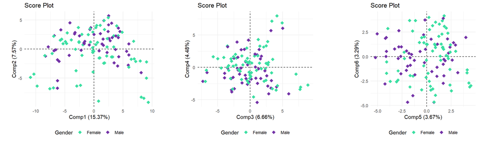

```r
p1 <- pcaPlot(species_pca, type = "scores", comp = 1:2,
              colBy = data.frame(Gender = species_meta$Gender),
              labels = FALSE, ellipses = FALSE)
p2 <- pcaPlot(species_pca, type = "scores", comp = 3:4,
              colBy = data.frame(Gender = species_meta$Gender),
              labels = FALSE, ellipses = FALSE)
p3 <- pcaPlot(species_pca, type = "scores", comp = 5:6,
              colBy = data.frame(Gender = species_meta$Gender),
              labels = FALSE, ellipses = FALSE)

grid.arrange(p1, p2, p3, ncol = 3)
```

#### Tipo de parto

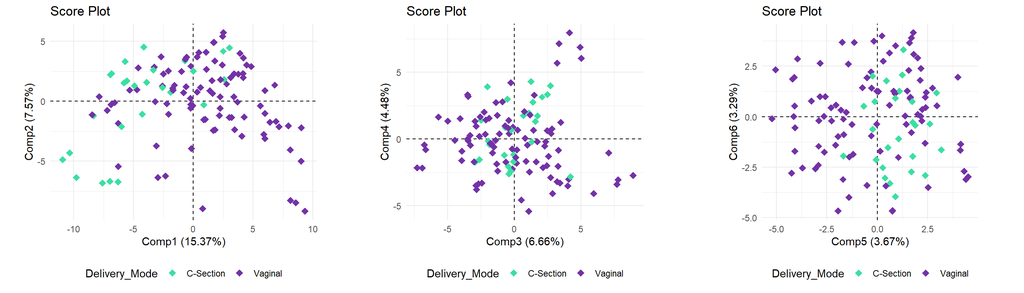

```r
p1 <- pcaPlot(species_pca, type = "scores", comp = 1:2,
              colBy = data.frame(Delivery_Mode = species_meta$Delivery_Mode),
              labels = FALSE, ellipses = FALSE)
p2 <- pcaPlot(species_pca, type = "scores", comp = 3:4,
              colBy = data.frame(Delivery_Mode = species_meta$Delivery_Mode),
              labels = FALSE, ellipses = FALSE)
p3 <- pcaPlot(species_pca, type = "scores", comp = 5:6,
              colBy = data.frame(Delivery_Mode = species_meta$Delivery_Mode),
              labels = FALSE, ellipses = FALSE)

grid.arrange(p1, p2, p3, ncol = 3)
```

#### Riesgo genético (HLA)

Los nombres de los perfiles de riesgo genético son largos, por lo que se abrevian para mejorar la legibilidad de la leyenda. La leyenda se muestra solo en el panel central.

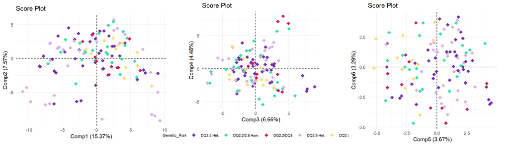

```r
genetic_risk_short <- species_meta$Genetic_Risk %>%
  str_replace_all("Homozygous", "Hom.") %>%
  str_replace_all("Heterozygous", "Het.")

p1 <- pcaPlot(species_pca, type = "scores", comp = 1:2,
              colBy = data.frame(Genetic_Risk = genetic_risk_short),
              labels = FALSE, ellipses = FALSE) +
  theme(legend.position = "none")

p2 <- pcaPlot(species_pca, type = "scores", comp = 3:4,
              colBy = data.frame(Genetic_Risk = genetic_risk_short),
              labels = FALSE, ellipses = FALSE) +
  theme(legend.position = "bottom",
        legend.text  = element_text(size = 7),
        legend.title = element_text(size = 8))

p3 <- pcaPlot(species_pca, type = "scores", comp = 5:6,
              colBy = data.frame(Genetic_Risk = genetic_risk_short),
              labels = FALSE, ellipses = FALSE) +
  theme(legend.position = "none")

grid.arrange(p1, p2, p3, ncol = 3)
```

### 4.2.3 Loadings — correlation plots y top variables

Los loadings indican qué especies contribuyen más a cada componente principal. El correlation plot muestra la correlación de cada variable con los ejes del PCA, coloreada por su contribución. Las tablas muestran las 10 especies con mayor contribución a cada par de componentes, lo que permite interpretar qué está impulsando la variabilidad capturada.

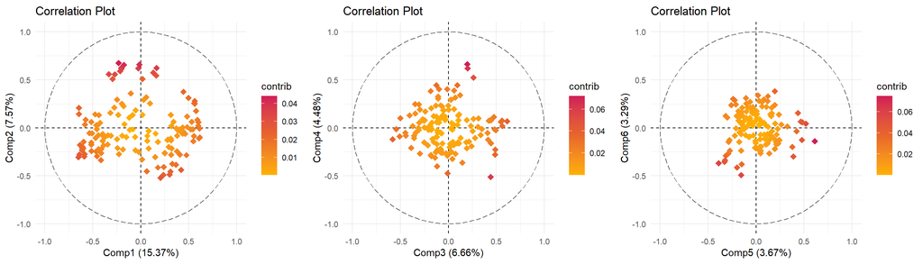

```r
l1 <- pcaPlot(species_pca, type = "corr", comp = 1:2,
              colBy = "contrib", shape = "point",
              labels = FALSE, repel = TRUE, col = "hot")
l2 <- pcaPlot(species_pca, type = "corr", comp = 3:4,
              colBy = "contrib", shape = "point",
              labels = FALSE, repel = TRUE, col = "hot")
l3 <- pcaPlot(species_pca, type = "corr", comp = 5:6,
              colBy = "contrib", shape = "point",
              labels = FALSE, repel = TRUE, col = "hot")

grid.arrange(l1, l2, l3, ncol = 3)
```

**Top 10 especies — PC1 y PC2**

```r
species_top_PC12 <- tibble(
  variable    = rownames(species_pca$loadings),
  loading_PC1 = species_pca$loadings[, 1],
  loading_PC2 = species_pca$loadings[, 2]
) %>%
  mutate(contribution_PC12 = loading_PC1^2 + loading_PC2^2) %>%
  arrange(desc(contribution_PC12)) %>%
  slice_head(n = 10)

kable(species_top_PC12)
```

| variable | loading_PC1 | loading_PC2 | contribution_PC12 |
| --- | --- | --- | --- |
| Clostridiales.bacterium | -0.0491465 | 0.2042677 | 0.0441407 |
| Erysipelotrichaceae.bacterium | -0.0373235 | 0.1981761 | 0.0406668 |
| Coprobacillus.sp. | -0.0028223 | 0.2001760 | 0.0400784 |
| Eggerthella.lenta | -0.0429354 | 0.1897265 | 0.0378396 |
| Clostridium.sp. | 0.0351346 | 0.1888087 | 0.0368832 |
| Eggerthella.sp. | -0.0425177 | 0.1868865 | 0.0367343 |
| Clostridium.bolteae | -0.0054113 | 0.1881438 | 0.0354274 |
| Erysipelatoclostridium.ramosum | -0.0455585 | 0.1786615 | 0.0339955 |
| Peptoclostridium.difficile | -0.0705551 | 0.1696798 | 0.0337692 |
| Clostridium.clostridioforme | -0.0572334 | 0.1687370 | 0.0317478 |

**Top 10 especies — PC3 y PC4**

```r
species_top_PC34 <- tibble(
  variable    = rownames(species_pca$loadings),
  loading_PC3 = species_pca$loadings[, 3],
  loading_PC4 = species_pca$loadings[, 4]
) %>%
  mutate(contribution_PC34 = loading_PC3^2 + loading_PC4^2) %>%
  arrange(desc(contribution_PC34)) %>%
  slice_head(n = 10)

kable(species_top_PC34)
```

| variable | loading_PC3 | loading_PC4 | contribution_PC34 |
| --- | --- | --- | --- |
| Prevotella.buccae | 0.0637615 | 0.2608800 | 0.0721239 |
| Prevotella.sp. | 0.0651322 | 0.2437848 | 0.0636733 |
| Ruminococcus.obeum | 0.1426134 | -0.2018542 | 0.0610837 |
| Dialister.invisus | 0.0842836 | 0.2061517 | 0.0496023 |
| Bifidobacterium.kashiwanohense | 0.1978478 | 0.0265624 | 0.0398493 |
| Bacteroides.stercoris | -0.1880436 | -0.0469562 | 0.0375653 |
| Dorea.formicigenerans | 0.1572157 | -0.1104524 | 0.0369165 |
| Streptococcus.australis | -0.0025844 | -0.1865876 | 0.0348216 |
| Bifidobacterium.catenulatum | 0.1804136 | 0.0303011 | 0.0334672 |
| Bifidobacterium.pseudocatenulatum | 0.1816428 | 0.0074678 | 0.0330499 |

**Top 10 especies — PC5 y PC6**

```r
species_top_PC56 <- tibble(
  variable    = rownames(species_pca$loadings),
  loading_PC5 = species_pca$loadings[, 5],
  loading_PC6 = species_pca$loadings[, 6]
) %>%
  mutate(contribution_PC56 = loading_PC5^2 + loading_PC6^2) %>%
  arrange(desc(contribution_PC56)) %>%
  slice_head(n = 10)

kable(species_top_PC56)
```

| variable | loading_PC5 | loading_PC6 | contribution_PC56 |
| --- | --- | --- | --- |
| Anaerotruncus.colihominis | 0.2662992 | -0.0635304 | 0.0749514 |
| Parabacteroides.sp. | -0.1699630 | -0.1700873 | 0.0578171 |
| Veillonella.parvula | -0.0675882 | -0.2267294 | 0.0559744 |
| Clostridiaceae.bacterium | 0.2259976 | 0.0194966 | 0.0514550 |
| Oscillospiraceae.bacterium | 0.1692833 | -0.1374181 | 0.0475406 |
| Porphyromonas.sp. | -0.1430336 | -0.1629671 | 0.0470169 |
| Eubacterium.ventriosum | 0.2085395 | -0.0579515 | 0.0468471 |
| Parasutterella.excrementihominis | 0.2103215 | 0.0271392 | 0.0449717 |
| Parabacteroides.distasonis | -0.1408794 | -0.1550447 | 0.0438859 |
| Veillonella.dispar | -0.0865530 | -0.1896967 | 0.0434763 |

Fijamos el número de componentes antes de estudiar los anómalos para evitar problemas con los gráficos.

```r
species_pca <- pca(
  species_X,
  ncomp   = 6,
  algo    = "nipals",
  scaling = "standard"
)
```

### 4.2.4 Detección de muestras anómalas

Se detectan muestras anómalas mediante dos criterios complementarios. El RSS y el T² de Hotelling.

```r
par(mfrow = c(1, 2))

species_out_RSS <- pcaOutliers(species_pca, ncomp = species_pca$ncomp,
                               method = "RSS", conf = 0.95)
species_out_T2  <- pcaOutliers(species_pca, ncomp = species_pca$ncomp,
                               method = "T2",  conf = 0.95)
```

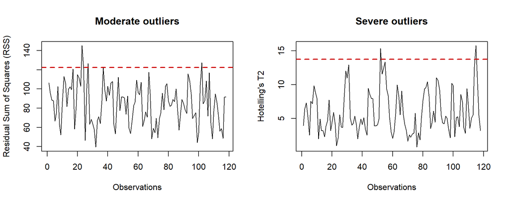

```r
par(mfrow = c(1, 1))
```

```r
species_moderate <- sort(
  species_out_RSS$RSS[species_out_RSS$ModerateOutliers],
  decreasing = TRUE
)

species_severe <- sort(
  species_out_T2$T2[species_out_T2$SevereOutliers],
  decreasing = TRUE
)

cat("Anómalos moderados (RSS) al 95 :\n"); print(species_moderate)
```

```
## Anómalos moderados (RSS) al 95 :
```

```
## Control_2_21_month Control_9_12_month    Case_3_12_month
##           145.2275           127.3191           126.4593
```

```r
cat("\nAnómalos severos (T²) al 95 :\n");   print(species_severe)
```

```
##
## Anómalos severos (T²) al 95 :
```

```
## Control_10_9_month Control_5_30_month
##           15.78539           15.37409
```

```r
par(mfrow = c(1, 2))

species_out_RSS_99 <- pcaOutliers(species_pca, ncomp = species_pca$ncomp,
                                  method = "RSS", conf = 0.99)
species_out_T2_99  <- pcaOutliers(species_pca, ncomp = species_pca$ncomp,
                                  method = "T2",  conf = 0.99)
```

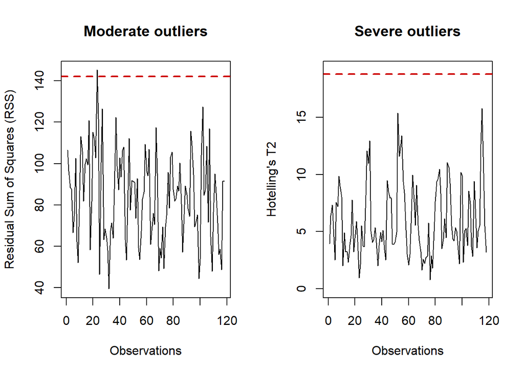

```r
par(mfrow = c(1, 1))
```

```r
moderate_99 <- sort(species_out_RSS_99$RSS[species_out_RSS_99$ModerateOutliers],
                    decreasing = TRUE)
severe_99   <- sort(species_out_T2_99$T2[species_out_T2_99$SevereOutliers],
                    decreasing = TRUE)

cat("Moderados (RSS) al 99 :\n"); print(moderate_99)
```

```
## Moderados (RSS) al 99 :
```

```
## Control_2_21_month
##           145.2275
```

```r
cat("Severos   (T²) al 99 :\n");  print(severe_99)
```

```
## Severos   (T²) al 99 :
```

```
## named numeric(0)
```

```r
species_contrib_99 <- outlierContrib(species_pca, species_out_RSS_99)
```

```
## There are no severe outliers in the data or they were not computed.
```

```
## There are 1 moderate outliers in the data provided.
```

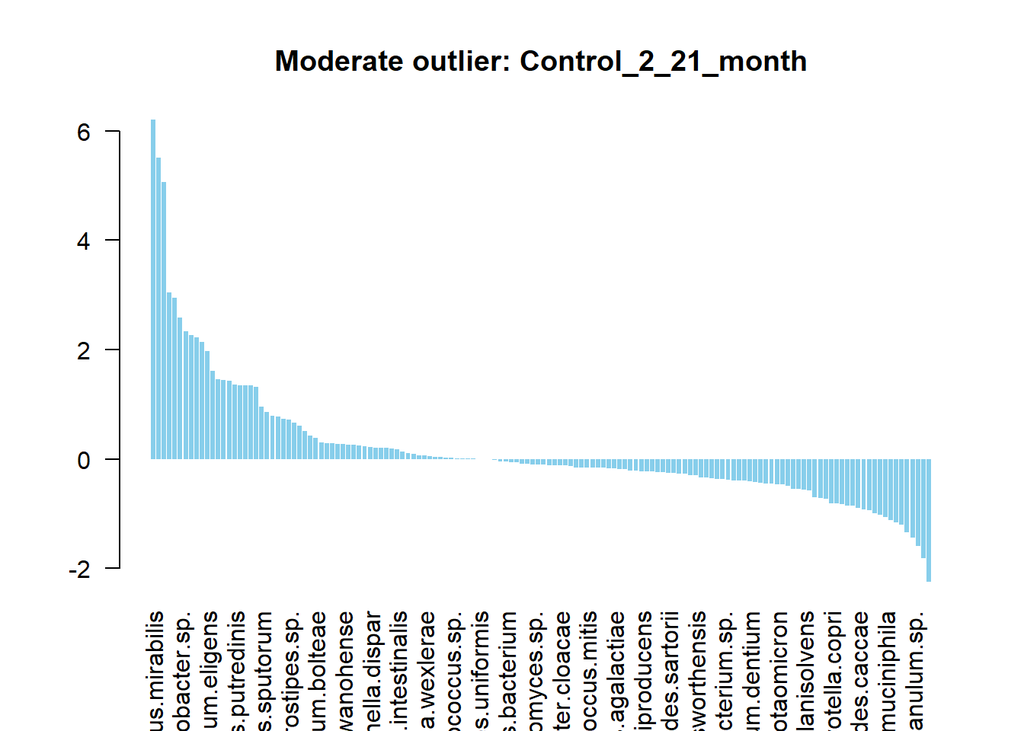

```r
contrib_vec <- species_contrib_99$contribRSS[1, ]
top10 <- contrib_vec[order(abs(contrib_vec), decreasing = TRUE)][1:10]
top10
```

```
##                Proteus.mirabilis Parasutterella.excrementihominis
##                         6.206245                         5.509653
##        Burkholderiales.bacterium         Odoribacter.splanchnicus
##                         5.068016                         3.045518
##            Klebsiella.pneumoniae                  Citrobacter.sp.
##                         2.948724                         2.587886
##             Enterococcus.faecium             Citrobacter.freundii
##                         2.332886                         2.264700
##              Anaerostipes.hadrus          Bacteroidales.bacterium
##                        -2.240908                         2.221107
```

Se reproduce el mismo flujo de trbajo tanto para Pathways como para Metabolites.

# 5. PCA — Pathways

## 5.1 Escalado: center

### 5.1.1 Cálculo y scree plot

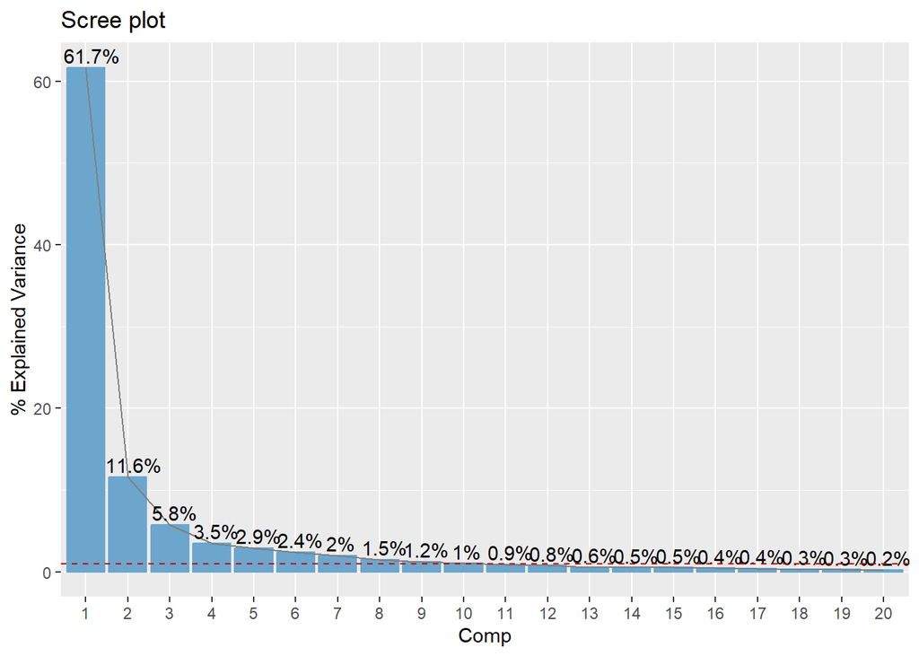

```r
pathways_pca_center <- pca(
  pathways_X,
  ncomp   = NULL,
  algo    = "nipals",
  scaling = "center"
)

pcaPlot(pathways_pca_center, type = "scree")
```

### 5.1.2 Score plots — coloreando por covariables de interés

#### Grupo (caso/control)

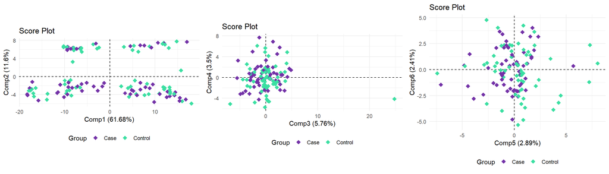

```r
p1 <- pcaPlot(pathways_pca_center, type = "scores", comp = 1:2,
              colBy = data.frame(Group = pathways_meta$group),
              labels = FALSE, ellipses = FALSE)
p2 <- pcaPlot(pathways_pca_center, type = "scores", comp = 3:4,
              colBy = data.frame(Group = pathways_meta$group),
              labels = FALSE, ellipses = FALSE)
p3 <- pcaPlot(pathways_pca_center, type = "scores", comp = 5:6,
              colBy = data.frame(Group = pathways_meta$group),
              labels = FALSE, ellipses = FALSE)

grid.arrange(p1, p2, p3, nrow = 1)
```

#### Tiempo relativo al diagnóstico

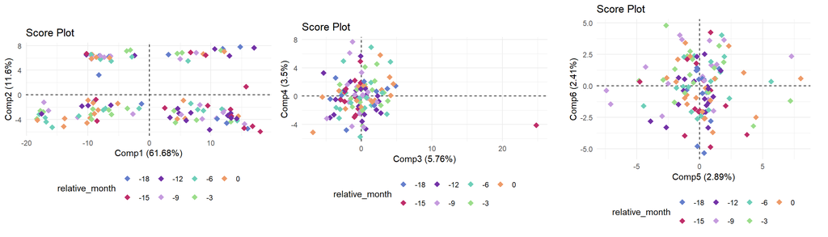

```r
pathways_time <- factor(pathways_meta$relative_month,
                        levels = c(-18, -15, -12, -9, -6, -3, 0))

p1 <- pcaPlot(pathways_pca_center, type = "scores", comp = 1:2,
              colBy = data.frame(relative_month = pathways_time),
              labels = FALSE, ellipses = FALSE)
p2 <- pcaPlot(pathways_pca_center, type = "scores", comp = 3:4,
              colBy = data.frame(relative_month = pathways_time),
              labels = FALSE, ellipses = FALSE)
p3 <- pcaPlot(pathways_pca_center, type = "scores", comp = 5:6,
              colBy = data.frame(relative_month = pathways_time),
              labels = FALSE, ellipses = FALSE)

grid.arrange(p1, p2, p3, nrow = 1)
```

#### País

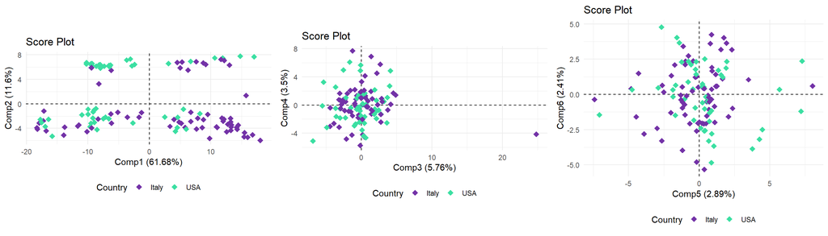

```r
p1 <- pcaPlot(pathways_pca_center, type = "scores", comp = 1:2,
              colBy = data.frame(Country = pathways_meta$Country),
              labels = FALSE, ellipses = FALSE)
p2 <- pcaPlot(pathways_pca_center, type = "scores", comp = 3:4,
              colBy = data.frame(Country = pathways_meta$Country),
              labels = FALSE, ellipses = FALSE)
p3 <- pcaPlot(pathways_pca_center, type = "scores", comp = 5:6,
              colBy = data.frame(Country = pathways_meta$Country),
              labels = FALSE, ellipses = FALSE)

grid.arrange(p1, p2, p3, nrow = 1)
```

#### Sexo

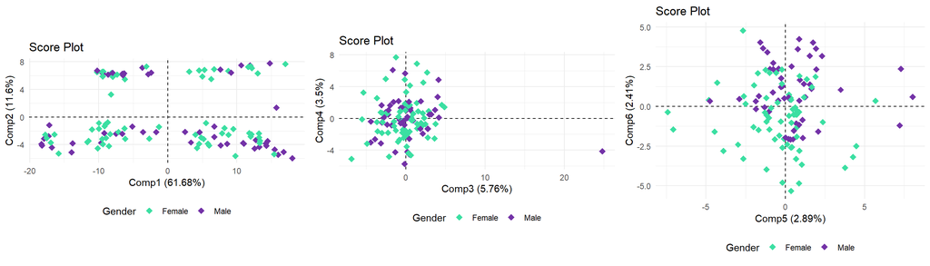

```r
p1 <- pcaPlot(pathways_pca_center, type = "scores", comp = 1:2,
              colBy = data.frame(Gender = pathways_meta$Gender),
              labels = FALSE, ellipses = FALSE)
p2 <- pcaPlot(pathways_pca_center, type = "scores", comp = 3:4,
              colBy = data.frame(Gender = pathways_meta$Gender),
              labels = FALSE, ellipses = FALSE)
p3 <- pcaPlot(pathways_pca_center, type = "scores", comp = 5:6,
              colBy = data.frame(Gender = pathways_meta$Gender),
              labels = FALSE, ellipses = FALSE)

grid.arrange(p1, p2, p3, ncol = 3)
```

#### Tipo de parto

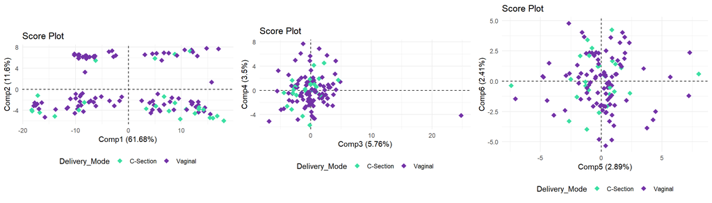

```r
p1 <- pcaPlot(pathways_pca_center, type = "scores", comp = 1:2,
              colBy = data.frame(Delivery_Mode = pathways_meta$Delivery_Mode),
              labels = FALSE, ellipses = FALSE)
p2 <- pcaPlot(pathways_pca_center, type = "scores", comp = 3:4,
              colBy = data.frame(Delivery_Mode = pathways_meta$Delivery_Mode),
              labels = FALSE, ellipses = FALSE)
p3 <- pcaPlot(pathways_pca_center, type = "scores", comp = 5:6,
              colBy = data.frame(Delivery_Mode = pathways_meta$Delivery_Mode),
              labels = FALSE, ellipses = FALSE)

grid.arrange(p1, p2, p3, ncol = 3)
```

#### Riesgo genético (HLA)

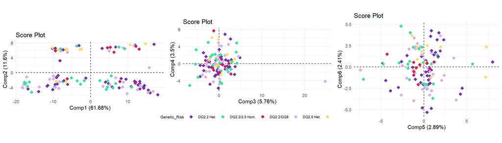

```r
genetic_risk_short <- pathways_meta$Genetic_Risk %>%
  str_replace_all("Homozygous", "Hom.") %>%
  str_replace_all("Heterozygous", "Het.")

p1 <- pcaPlot(pathways_pca_center, type = "scores", comp = 1:2,
              colBy = data.frame(Genetic_Risk = genetic_risk_short),
              labels = FALSE, ellipses = FALSE) +
  theme(legend.position = "none")

p2 <- pcaPlot(pathways_pca_center, type = "scores", comp = 3:4,
              colBy = data.frame(Genetic_Risk = genetic_risk_short),
              labels = FALSE, ellipses = FALSE) +
  theme(legend.position = "bottom",
        legend.text  = element_text(size = 7),
        legend.title = element_text(size = 8))

p3 <- pcaPlot(pathways_pca_center, type = "scores", comp = 5:6,
              colBy = data.frame(Genetic_Risk = genetic_risk_short),
              labels = FALSE, ellipses = FALSE) +
  theme(legend.position = "none")

grid.arrange(p1, p2, p3, ncol = 3)
```

### 5.1.3 Loadings — correlation plots y top variables

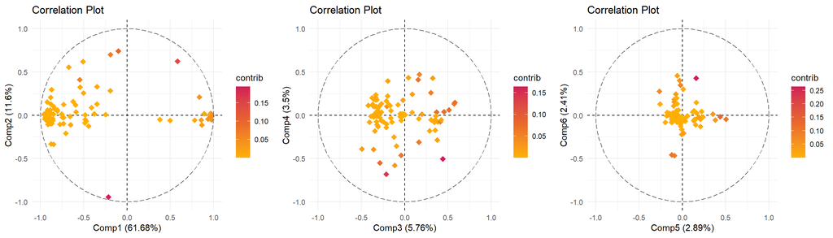

```r
l1 <- pcaPlot(pathways_pca_center, type = "corr", comp = 1:2,
              colBy = "contrib", shape = "point",
              labels = FALSE, repel = TRUE, col = "hot")
l2 <- pcaPlot(pathways_pca_center, type = "corr", comp = 3:4,
              colBy = "contrib", shape = "point",
              labels = FALSE, repel = TRUE, col = "hot")
l3 <- pcaPlot(pathways_pca_center, type = "corr", comp = 5:6,
              colBy = "contrib", shape = "point",
              labels = FALSE, repel = TRUE, col = "hot")

grid.arrange(l1, l2, l3, ncol = 3)
```

**Top 10 pathways — PC1 y PC2**

```r
pathways_top_PC12_center <- tibble(
  variable    = rownames(pathways_pca_center$loadings),
  loading_PC1 = pathways_pca_center$loadings[, 1],
  loading_PC2 = pathways_pca_center$loadings[, 2]
) %>%
  mutate(contribution_PC12 = loading_PC1^2 + loading_PC2^2) %>%
  arrange(desc(contribution_PC12)) %>%
  slice_head(n = 10)

kable(pathways_top_PC12_center)
```

| variable | loading_PC1 | loading_PC2 | contribution_PC12 |
| --- | --- | --- | --- |
| Human.papillomavirus.infection | -0.0431876 | -0.4392465 | 0.1948027 |
| Relaxin.signaling.pathway | -0.0431876 | -0.4392465 | 0.1948027 |
| Thermogenesis | -0.0431876 | -0.4392465 | 0.1948027 |
| Ascorbate.and.aldarate.metabolism | 0.1417225 | 0.3500076 | 0.1425906 |
| Synthesis.and.degradation.of.ketone.bodies | -0.0179320 | 0.3093267 | 0.0960046 |
| Penicillin.and.cephalosporin.biosynthesis | -0.0300991 | 0.2532562 | 0.0650447 |
| Ether.lipid.metabolism | -0.1221220 | 0.2118705 | 0.0598029 |
| Fatty.acid.metabolism | 0.2182735 | 0.0073255 | 0.0476970 |
| Fatty.acid.elongation.in.mitochondria | 0.2077317 | -0.0041797 | 0.0431699 |
| Geraniol.degradation | 0.2077317 | -0.0041797 | 0.0431699 |

**Top 10 pathways — PC3 y PC4**

```r
pathways_top_PC34_center <- tibble(
  variable    = rownames(pathways_pca_center$loadings),
  loading_PC3 = pathways_pca_center$loadings[, 3],
  loading_PC4 = pathways_pca_center$loadings[, 4]
) %>%
  mutate(contribution_PC34 = loading_PC3^2 + loading_PC4^2) %>%
  arrange(desc(contribution_PC34)) %>%
  slice_head(n = 10)

kable(pathways_top_PC34_center)
```

| variable | loading_PC3 | loading_PC4 | contribution_PC34 |
| --- | --- | --- | --- |
| Biphenyl.degradation | 0.2287917 | -0.3345460 | 0.1642667 |
| Toluene.and.xylene.degradation | 0.2287917 | -0.3345460 | 0.1642667 |
| Lipoic.acid.metabolism | -0.0882849 | -0.3629742 | 0.1395445 |
| Lipopolysaccharide.biosynthesis | -0.1036260 | -0.2558377 | 0.0761913 |
| Ether.lipid.metabolism | 0.2709433 | 0.0335064 | 0.0745329 |
| Tetrachloroethene.degradation | 0.2589164 | 0.0837378 | 0.0740497 |
| Synthesis.and.degradation.of.ketone.bodies | 0.2686253 | 0.0298670 | 0.0730516 |
| Penicillin.and.cephalosporin.biosynthesis | 0.2631415 | 0.0396413 | 0.0708149 |
| Streptomycin.biosynthesis | 0.0723488 | 0.2451819 | 0.0653485 |
| Phosphonate.and.phosphinate.metabolism | -0.0176028 | -0.2532400 | 0.0644404 |

**Top 10 pathways — PC5 y PC6**

```r
pathways_top_PC56_center <- tibble(
  variable    = rownames(pathways_pca_center$loadings),
  loading_PC5 = pathways_pca_center$loadings[, 5],
  loading_PC6 = pathways_pca_center$loadings[, 6]
) %>%
  mutate(contribution_PC56 = loading_PC5^2 + loading_PC6^2) %>%
  arrange(desc(contribution_PC56)) %>%
  slice_head(n = 10)

kable(pathways_top_PC56_center)
```

| variable | loading_PC5 | loading_PC6 | contribution_PC56 |
| --- | --- | --- | --- |
| Ether.lipid.metabolism | 0.1648064 | 0.4870601 | 0.2643887 |
| Glycosaminoglycan.degradation | 0.3644098 | -0.0171789 | 0.1330896 |
| Glycosphingolipid.biosynthesis…ganglio.series | 0.3644098 | -0.0171789 | 0.1330896 |
| Other.glycan.degradation | 0.3644098 | -0.0171789 | 0.1330896 |
| Tetrachloroethene.degradation | -0.0765922 | -0.3156378 | 0.1054936 |
| Glycosphingolipid.biosynthesis…globo.series | 0.3155562 | -0.0311509 | 0.1005461 |
| High.mannose.type.N.glycan.biosynthesis | 0.3155562 | -0.0311509 | 0.1005461 |
| Fluorobenzoate.degradation | -0.0515434 | -0.2910638 | 0.0873749 |
| Styrene.degradation | -0.0515434 | -0.2910638 | 0.0873749 |
| Atrazine.degradation | -0.0156200 | 0.2834563 | 0.0805915 |

Fijamos el número de componentes antes de estudiar los anómalos para evitar problemas con los gráficos.

```r
pathways_pca_center <- pca(
  pathways_X,
  ncomp   = 4,
  algo    = "nipals",
  scaling = "center"
)
```

### 5.1.4 Detección de muestras anómalas

```r
par(mfrow = c(1, 2))

pathways_out_RSS_center <- pcaOutliers(pathways_pca_center, ncomp = pathways_pca_center$ncomp,
                               method = "RSS", conf = 0.95)
pathways_out_T2_center  <- pcaOutliers(pathways_pca_center, ncomp = pathways_pca_center$ncomp,
                               method = "T2",  conf = 0.95)
```

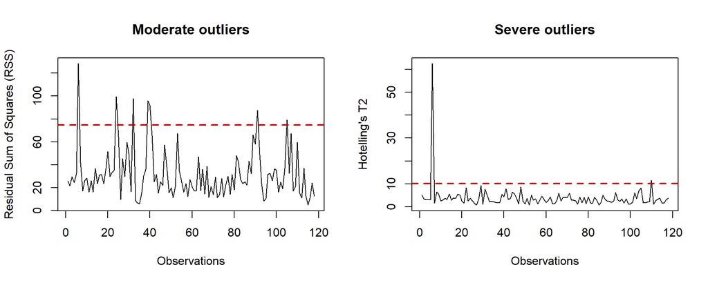

```r
par(mfrow = c(1, 1))
```

```r
pathways_moderate_center <- sort(
  pathways_out_RSS_center$RSS[pathways_out_RSS_center$ModerateOutliers],
  decreasing = TRUE
)

pathways_severe_center <- sort(
  pathways_out_T2_center$T2[pathways_out_T2_center$SevereOutliers],
  decreasing = TRUE
)

cat("Anómalos moderados (RSS) al 95 :\n"); print(pathways_moderate_center)
```

```
## Anómalos moderados (RSS) al 95 :
```

```
##   Control_1_3_month  Control_2_24_month Control_3_4-6_month    Case_4_4-6_month
##           128.30600            99.56187            97.79074            95.86777
##      Case_4_9_month   Control_8_9_month  Control_9_21_month
##            92.13580            87.42286            79.36302
```

```r
cat("\nAnómalos severos (T²) al 95 :\n");   print(pathways_severe_center)
```

```
##
## Anómalos severos (T²) al 95 :
```

```
## Control_1_3_month   Case_10_9_month
##          62.46490          11.63043
```

```r
par(mfrow = c(1, 2))

pathways_out_RSS_99_center <- pcaOutliers(pathways_pca_center, ncomp = pathways_pca_center$ncomp,method = "RSS", conf = 0.99)

pathways_out_T2_99_center  <- pcaOutliers(pathways_pca_center, ncomp = pathways_pca_center$ncomp,method = "T2",  conf = 0.99)
```

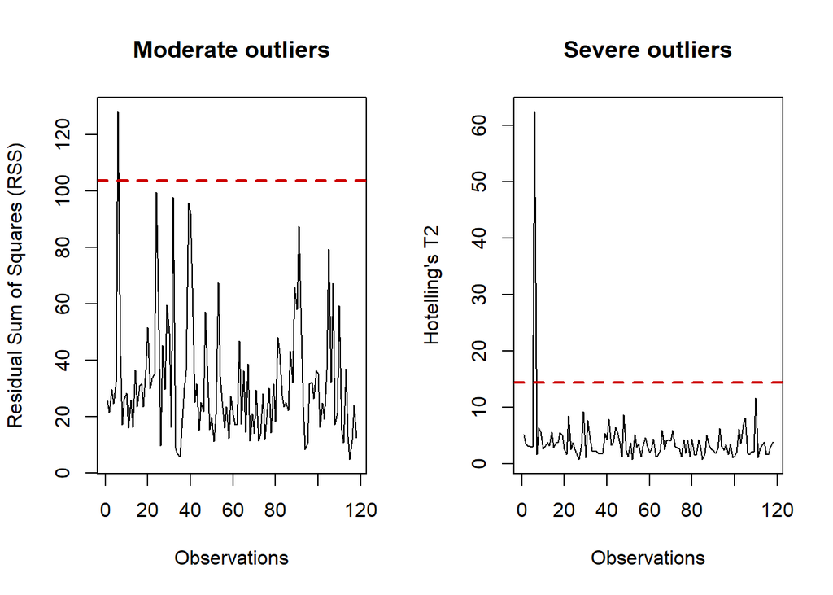

```r
par(mfrow = c(1, 1))
```

```r
pathways_moderate_99_center <- sort(pathways_out_RSS_99_center$RSS[pathways_out_RSS_99_center$ModerateOutliers],
                    decreasing = TRUE)
pathways_severe_99_center   <- sort(pathways_out_T2_99_center$T2[pathways_out_T2_99_center$SevereOutliers],
                    decreasing = TRUE)

cat("Moderados (RSS) al 99 :\n"); print(pathways_moderate_99_center)
```

```
## Moderados (RSS) al 99 :
```

```
## Control_1_3_month
##           128.306
```

```r
cat("Severos   (T²) al 99 :\n");  print(pathways_severe_99_center)
```

```
## Severos   (T²) al 99 :
```

```
## Control_1_3_month
##           62.4649
```